# Football Scouting Report Presentation

Liam Cook

2025-04-14

## Abstract & Research Questions

This project investigates offensive play-calling tendencies in Nova Scotia high school football. I manually tagged five games, analyzing each play based on situation and play type.

I aimed to answer two key questions: 1. How often does a team run or pass based on down and distance? 2. Which formations are strongly predictive of run vs. pass?

## Dataset Overview

- **Source**: Manually tagged game film from 2024–2025 season
- **Categorical variables**:  
  `Offense_Team`, `Play_Type`, `Offense_Formation`, `Field_Zone`
- **Quantitative variables**:  
  `Start_Yardline`, `Down`, `Distance`

## Team-Level Run vs Pass Tendencies by Down

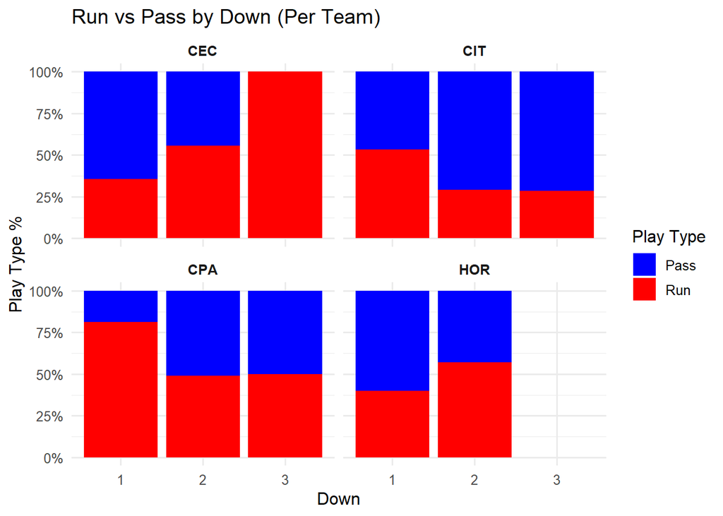

Team Tendencies

### Team Play Calling by Down

- Highlights variation in play calling across teams
- Run-heavy vs pass-heavy tendencies by down

## Summary: Pass Rate by Down and Distance

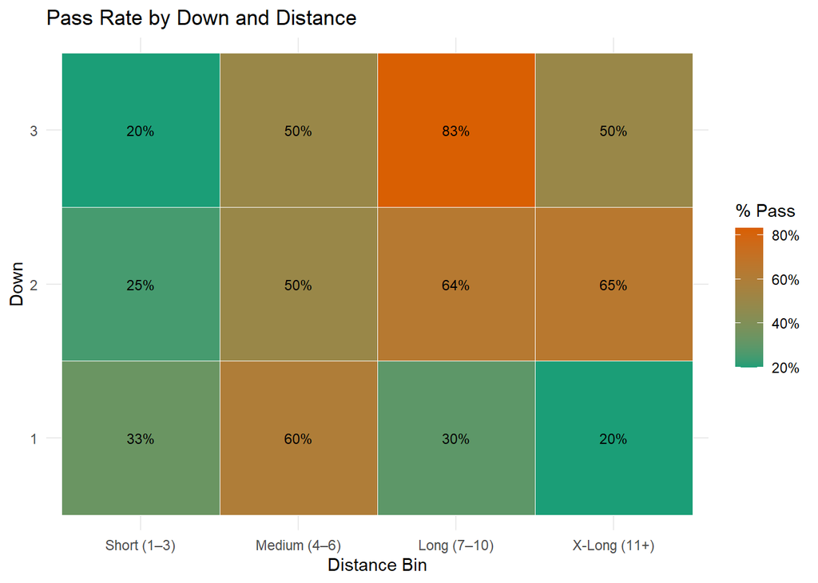

Heatmap

### Heatmap Summary

- Higher % pass on 2nd/3rd & long
- Lower % pass on early downs or short yardage

## First Down Pass Rates by Distance

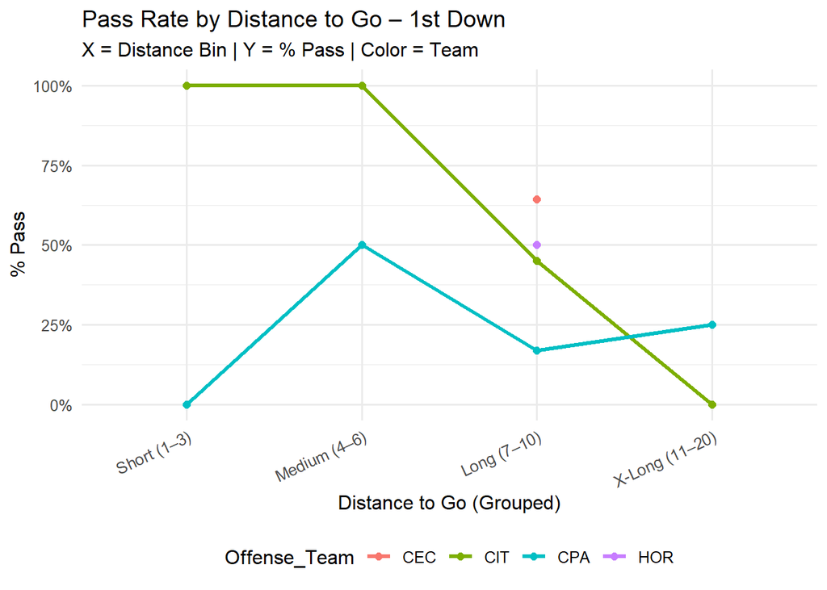

First Down

## Second Down Pass Rates by Distance

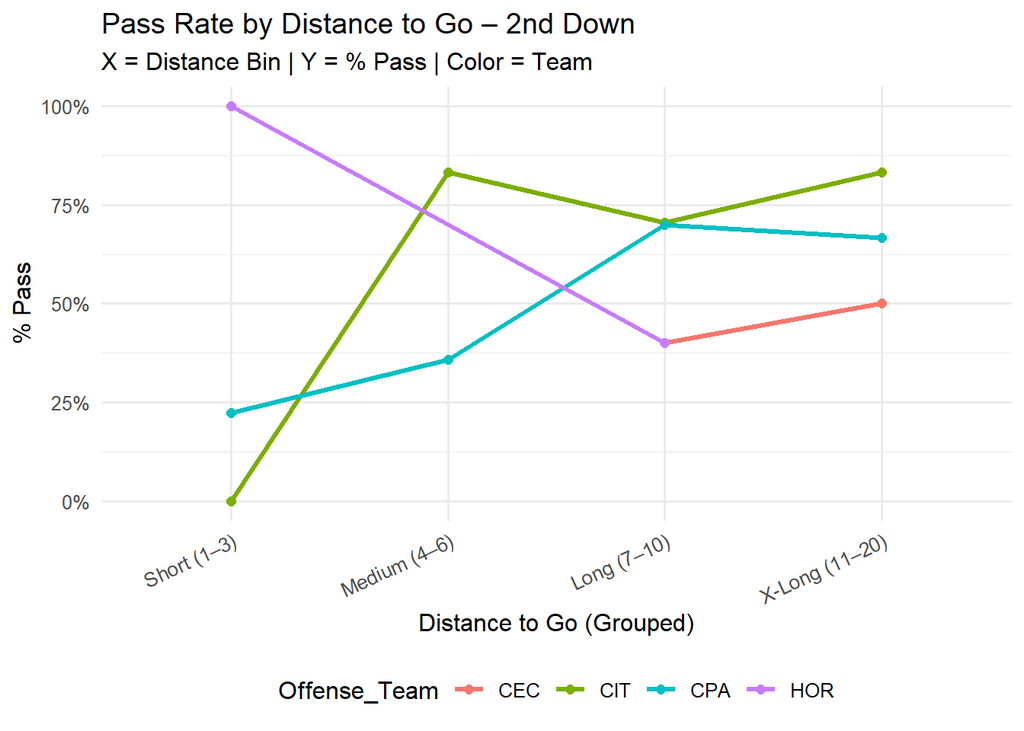

Second Down

### Trends on 2nd Down

- More aggressive play calling emerges
- CIT passes more as distance increases

## Formation vs Play Type Tendencies

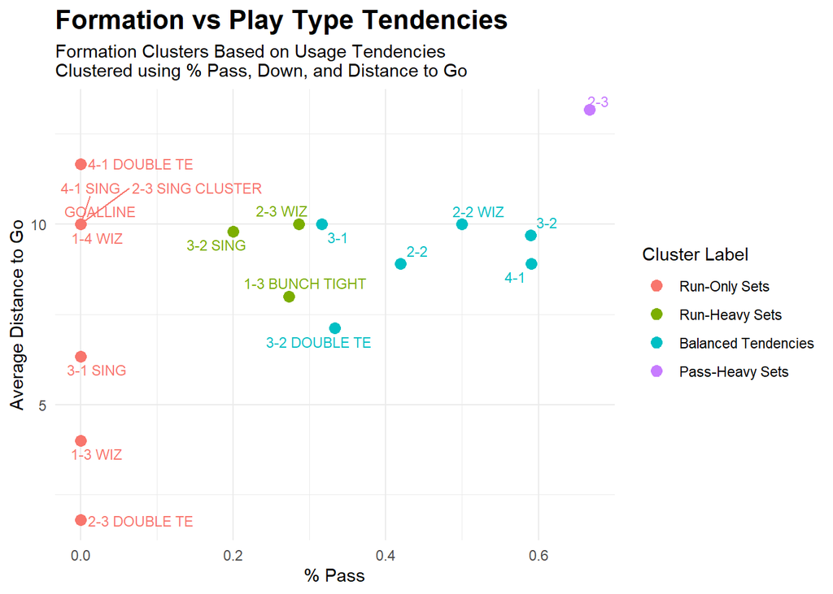

KMeans

### K-Means Clustering

- Clusters formations by % pass, avg down, and distance
- Labels: Run-Only, Run-Heavy, Balanced, Pass-Heavy

## Run vs Pass Percentages by Formation

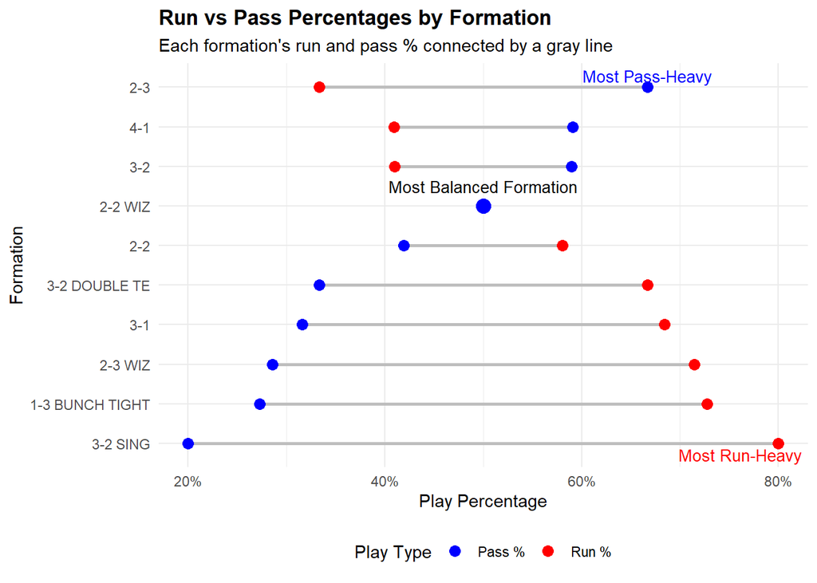

Dumbbell

### Dumbbell Chart

- Spread between run/pass shown per formation
- Flags most extreme & balanced formations

## Conclusion & Thank you!!!

### Key Takeaways

- Strong tendencies exist by team, down, and formation
- Situational awareness is critical (distance + down)
- Formations strongly indicate play type in many cases

## Thank You

Thanks for watching!  
I’m happy to answer any follow-up questions.

## Contributions & References

**Liam Cook** – Sole contributor to the analysis, report, and presentation.

## References

- ggplot2 Documentation: https://ggplot2.tidyverse.org/
- Plotly for R: https://plotly.com/
- ggrepel Documentation: https://ggrepel.slowkow.com/
- Tidyverse Project: https://www.tidyverse.org/
- Quarto RStudio Tutorial: https://quarto.org/docs/get-started/hello/rstudio.html